# winedata

对wine reviews数据集进行分析

```python
import pandas as pd
import numpy as np
import copy
from scipy import stats
from collections import Counter
import matplotlib.pyplot as plt
from fancyimpute import KNN
import re
```

```python
wine_path = "D:\\数据挖掘课件视频\\数据集\\2\\wine-reviews\\winemag-data-130k-v2.csv"
wine_data = pd.read_csv(wine_path)
wine_data2 = copy.deepcopy(wine_data)#深拷贝
wine_data3 = copy.deepcopy(wine_data)#深拷贝
wine_data4 = copy.deepcopy(wine_data)#深拷贝
wine_list = wine_data.columns.values.tolist()
print(wine_list)
```

```
['Unnamed: 0', 'country', 'description', 'designation', 'points', 'price', 'province', 'region_1', 'region_2', 'taster_name', 'taster_twitter_handle', 'title', 'variety', 'winery']
```

一、标称属性，给出每个可能聚会的频数。标称属性有'country', 'designation','province', 'region_1', 'region_2', 'taster_name', 'taster_twitter_handle', 'variety', 'winery'。首先统计输出了每个标称属性中聚会的频数。然后由于属性值类别太多，而且出现频数差距较大，因此，在用条形图可视化显示聚会频数时，每个属性都只显示出现频数在前25的属性值，这样也已涵盖绝大多数数据还方便观察。

```
The distribution of country
 US                        54504
France                    22093
Italy                     19540
Spain                      6645
Portugal                   5691
Chile                      4472
Argentina                  3800
Austria                    3345
Australia                  2329
Germany                    2165
New Zealand                1419
South Africa               1401
Israel                      505
Greece                      466
Canada                      257
Hungary                     146
Bulgaria                    141
Romania                     120
Uruguay                     109
Turkey                       90
Slovenia                     87
Georgia                      86
England                      74
Croatia                      73
Mexico                       70
Moldova                      59
Brazil                       52
Lebanon                      35
Morocco                      28
Peru                         16
Ukraine                      14
Macedonia                    12
Czech Republic               12
Serbia                       12
Cyprus                       11
India                         9
Switzerland                   7
Luxembourg                    6
Armenia                       2
```

[output cut: 112 more lines]

```
Frankovka                       1
Name: variety, Length: 707, dtype: int64
The distribution of winery
 Wines & Winemakers    222
Testarossa            218
DFJ Vinhos            215
Williams Selyem       211
Louis Latour          199
                     ...
Winner's Tank           1
Wallace                 1
Villa Travignoli        1
M. Autumn               1
Hinojosa                1
Name: winery, Length: 16757, dtype: int64
```

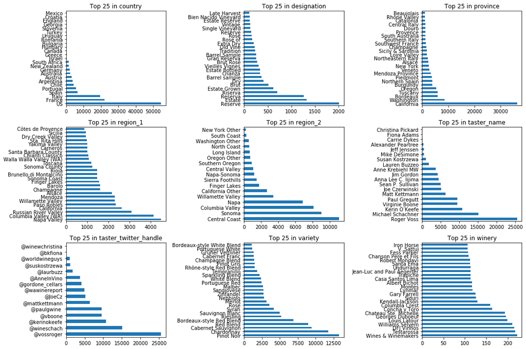

```python
country=wine_data['country'].value_counts()
designation=wine_data['designation'].value_counts()
province=wine_data['province'].value_counts()
region_1=wine_data['region_1'].value_counts()
region_2=wine_data['region_2'].value_counts()
taster_name=wine_data['taster_name'].value_counts()
taster_twitter_handle=wine_data['taster_twitter_handle'].value_counts()
variety=wine_data['variety'].value_counts()
winery=wine_data['winery'].value_counts()
print("The distribution of country\n",country)
print("The distribution of designation\n",designation)
print("The distribution of province\n",province)
print("The distribution of region_1\n",region_1)
print("The distribution of region_2\n",region_2)
print("The distribution of taster_name\n",taster_name)
print("The distribution of taster_twitter_handle\n",taster_twitter_handle)
print("The distribution of variety\n",variety)
print("The distribution of winery\n",winery)
top=25
list_nominal=[country[:top],designation[:top],province[:top],region_1[:top],region_2[:top],taster_name[:top],taster_twitter_handle[:top],variety[:top],winery[:top]]
list_name=['country','designation','province','region_1','region_2','taster_name','taster_twitter_handle','variety','winery']
fig,axes=plt.subplots(3,3)
for d,i in zip(list_nominal,range(9)):
    ax=axes.ravel()[i]
    ax.set_title(f"Top 25 in {list_name[i]}")
    d.plot.barh(ax=ax,figsize=(15,10))
    plt.tight_layout()
```

二、数值属性，给出5数概括及缺失值的个数。数值属性有points,price。下面分别计算它们的5数以及缺失值个数。

```
                    index  missNum  missRate
8                region_2    79460  0.611367
3             designation    37465  0.288257
10  taster_twitter_handle    31213  0.240154
9             taster_name    26244  0.201922
7                region_1    21247  0.163475
5                   price     8996  0.069215
1                 country       63  0.000485
6                province       63  0.000485
12                variety        1  0.000008
0              Unnamed: 0        0  0.000000
2             description        0  0.000000
4                  points        0  0.000000
11                  title        0  0.000000
13                 winery        0  0.000000
```

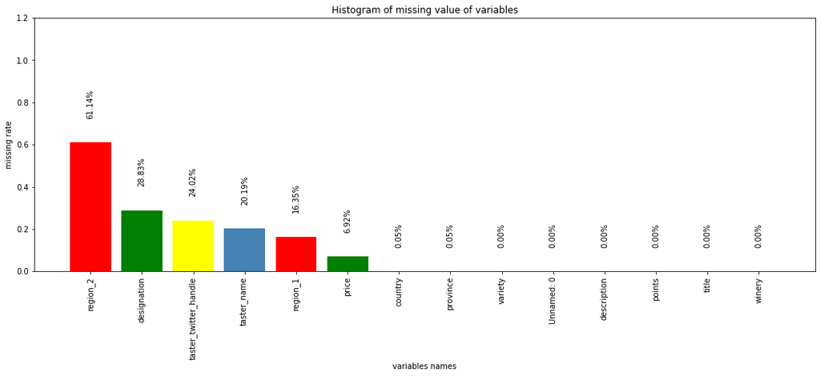

```python
# 统计缺失值数量
missing=wine_data.isnull().sum().reset_index().rename(columns={0:'missNum'})
# 计算缺失比例
missing['missRate']=missing['missNum']/wine_data.shape[0]
# 按照缺失率排序显示
miss_analy=missing[missing.missRate>=0].sort_values(by='missRate',ascending=False)
print(miss_analy)
# miss_analy 存储的是每个变量缺失情况的数据框
fig = plt.figure(figsize=(18,6))
plt.bar(np.arange(miss_analy.shape[0]), list(miss_analy.missRate.values), align = 'center',color=['red','green','yellow','steelblue'])

plt.title('Histogram of missing value of variables')
plt.xlabel('variables names')
plt.ylabel('missing rate')
# 添加x轴标签，并旋转90度
plt.xticks(np.arange(miss_analy.shape[0]),list(miss_analy['index']))
plt.xticks(rotation=90)
# 添加数值显示
for x,y in enumerate(list(miss_analy.missRate.values)):
    plt.text(x,y+0.12,'{:.2%}'.format(y),ha='center',rotation=90)
plt.ylim([0,1.2])

plt.show()
```

```python
#去掉缺失值计算五数
wine_data.dropna(subset=['points'], inplace=True)
wine_data.dropna(subset=['price'], inplace=True)
#中位数
Median_po = np.median(wine_data.points)
Median_pr = np.median(wine_data.price)
#四分之一分位数
Q1_po = np.percentile(wine_data.points, 25)
Q1_pr = np.percentile(wine_data.price, 25)
#四分之三中位数
Q3_po = np.percentile(wine_data.points, 75)
Q3_pr = np.percentile(wine_data.price, 75)
#最大值
max_po = np.amax(wine_data.points)
max_pr = np.amax(wine_data.price)
#最小值
min_po = np.amin(wine_data.points)
min_pr = np.amin(wine_data.price)
#IQR
IQR_po = Q3_po - Q1_po
IQR_pr = Q3_pr - Q1_pr
#Minimum
Minimum_po = max(Q1_po - 1.5 * IQR_po,min_po)
Minimum_pr = max(Q1_pr - 1.5 * IQR_pr,min_pr)
#Maximum
Maximum_po=min(Q3_po + 1.5 * IQR_po,max_po)
Maximum_pr=min(Q3_pr + 1.5 * IQR_pr,max_pr)
#五数输出
print("The Five-number of points： Minimum, Q1, Median, Q3, Maximum", Minimum_po, Q1_po, Median_po, Q3_po, Maximum_po)
print("The Five-number of price： Minimum, Q1, Median, Q3, Maximum", Minimum_pr, Q1_pr, Median_pr, Q3_pr, Maximum_pr)
```

```
The Five-number of points： Minimum, Q1, Median, Q3, Maximum 80 86.0 88.0 91.0 98.5
The Five-number of price： Minimum, Q1, Median, Q3, Maximum 4.0 17.0 25.0 42.0 79.5
```

三、数据可视化，使用直方图、盒图等检查数据分布及离群点

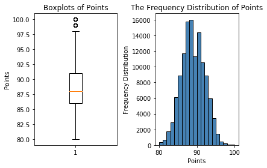

```python
#画盒图
plt.subplot(1,2,1)
plt.boxplot(x=wine_data.points)
# 添加y轴标签
plt.ylabel('Points')
# 添加标题
plt.title('Boxplots of Points')
plt.tight_layout()

plt.subplot(1,2,2)
plt.hist(x = wine_data.points, # 指定绘图数据
         bins = 20, # 指定直方图中条块的个数
         color = 'steelblue', # 指定直方图的填充色
         edgecolor = 'black' # 指定直方图的边框色
         )
# 添加x轴和y轴标签
plt.xlabel('Points')
plt.ylabel('Frequency Distribution')
# 添加标题
plt.title('The Frequency Distribution of Points')
plt.tight_layout()
plt.show()
```

由上图可以看出酒的分数比较接近正态分布，离散点只有两个。

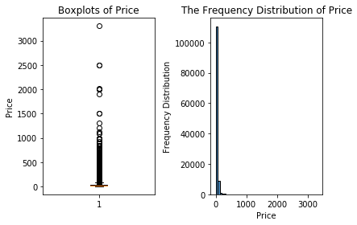

```python
#画盒图
plt.subplot(1,2,1)
plt.boxplot(x=wine_data.price)
# 添加y轴标签
plt.ylabel('Price')
# 添加标题
plt.title('Boxplots of Price')
plt.tight_layout()

plt.subplot(1,2,2)
plt.hist(x = wine_data.price, # 指定绘图数据
         bins = 50, # 指定直方图中条块的个数
         color = 'steelblue', # 指定直方图的填充色
         edgecolor = 'black' # 指定直方图的边框色
         )
# 添加x轴和y轴标签
plt.xlabel('Price')
plt.ylabel('Frequency Distribution')
# 添加标题
plt.title('The Frequency Distribution of Price')
plt.tight_layout()
plt.show()
```

由上图可看出酒的价格比较分散，悬殊较大，主要集中在4-79之间，最贵的高达3300。

四、观察数据集中缺失数据，分析其缺失的原因。分别使用下列四种策略对缺失值进行处理: 1、将缺失部分剔除 2、用最高频率值来填补缺失值 3、通过属性的相关关系来填补缺失值 4、通过数据对象之间的相似性来填补缺失值 因为point没有缺失值，所以只需处理price数据

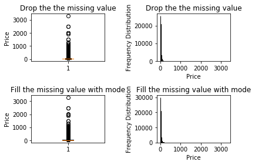

```python
#1、将缺失部分剔除的盒图和直方图
plt.subplot(2,2,1)
wine_data.dropna(subset=['price'], inplace=True)
plt.boxplot(x=wine_data.price)
# 添加y轴标签
plt.ylabel('Price')
# 添加标题
plt.title('Drop the the missing value')
plt.tight_layout()
plt.subplot(2,2,2)
plt.hist(x = wine_data.price, # 指定绘图数据
         bins = 500, # 指定直方图中条块的个数
         color = 'orange', # 指定直方图的填充色
         edgecolor = 'black' # 指定直方图的边框色
         )
# 添加x轴和y轴标签
plt.xlabel('Price')
plt.ylabel('Frequency Distribution')
# 添加标题
plt.title('Drop the the missing value')
plt.tight_layout()

#2、将用最高频率值来填补缺失值的盒图和直方图
plt.subplot(2,2,3)
mode=stats.mode(wine_data2['price'])[0][0]
wine_data2['price']=wine_data2['price'].fillna(mode)
plt.boxplot(x = wine_data2.price)
# 添加y轴标签
plt.ylabel('Price')
# 添加标题
plt.title('Fill the missing value with mode')
plt.tight_layout()
plt.subplot(2,2,4)
plt.hist(x = wine_data2.price, # 指定绘图数据
         bins = 500, # 指定直方图中条块的个数
         color = 'orange', # 指定直方图的填充色
         edgecolor = 'black' # 指定直方图的边框色
         )
# 添加x轴和y轴标签
plt.xlabel('Price')
plt.ylabel('Frequency Distribution')
# 添加标题
plt.title('Fill the missing value with mode')
plt.tight_layout()
plt.show()
```

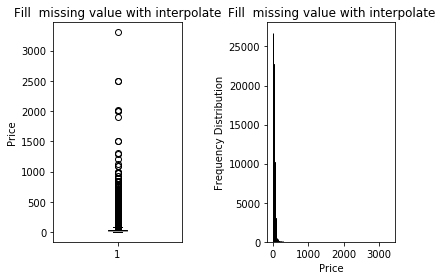

```python
#3、通过属性的相关关系来填补缺失值
#interpolate()插值法,计算的是缺失值前一个值和后一个值的平均数，无法解决第一个值为空值的情况，所以直接把第二个值赋给第一个值
wine_data3['price'] = wine_data3['price'].interpolate()
wine_data3['price'][0]=wine_data3['price'][1]
plt.subplot(1,2,1)
plt.boxplot(x=wine_data3.price)
# 添加y轴标签
plt.ylabel('Price')
# 添加标题
plt.title('Fill  missing value with interpolate')
plt.tight_layout()
plt.subplot(1,2,2)
plt.hist(x =wine_data3.price, # 指定绘图数据
         bins = 500, # 指定直方图中条块的个数
         color = 'orange', # 指定直方图的填充色
         edgecolor = 'black' # 指定直方图的边框色
         )
# 添加x轴和y轴标签
plt.xlabel('Price')
plt.ylabel('Frequency Distribution')
# 添加标题
plt.title('Fill  missing value with interpolate')
plt.tight_layout()
plt.show()
```

```python
#4、通过数据对象之间的相似性来填补缺失值
#选用knn，找出与缺失数据最相似的k的数据对象的值来填充
testdata=wine_data4[['price','points']]
x=[]
#KNN缺失数据填补
def knn_filled(testdata) :
    df = testdata
    #缺失填补
    if df.price.isnull().any():#判断数据是否有null
        data = pd.DataFrame()
        for i in range(0,df.shape[0],6):# 以60分钟为周期分段（10分钟粒度, 6个为周期）
            data1 = df["price"][i:i+6].reset_index(drop = True).rename(index = str(i))
            data = pd.concat((data, data1), axis = 1) #整合为一个dataframe，多个列
        data_incomplete = np.array(data)#转为array
        #预测缺失值
        filled_knn = KNN(k=3).fit_transform(data_incomplete)#利用knn填补缺失值
        data_complete = pd.DataFrame(filled_knn)#保存结果
        for i in range(0,data_complete.shape[1]):
            x.extend(data_complete[i].values.tolist())
    return x

paintdata=knn_filled(testdata)
```

```
Imputing row 1/6 with 1543 missing, elapsed time: 0.017
[KNN] Warning: 534/129972 still missing after imputation, replacing with 0
```

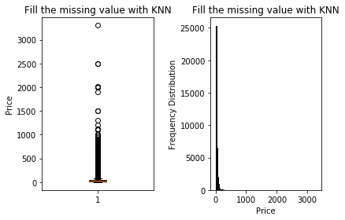

```python
# plt.figure(figsize=(10,10))
#将缺失部分剔除的盒图和直方图
plt.subplot(1,2,1)
plt.boxplot(x=paintdata)
# 添加y轴标签
plt.ylabel('Price')
# 添加标题
plt.title('Fill the missing value with KNN')
plt.tight_layout()
plt.subplot(1,2,2)
plt.hist(x = paintdata, # 指定绘图数据
         bins = 500, # 指定直方图中条块的个数
         color = 'orange', # 指定直方图的填充色
         edgecolor = 'black' # 指定直方图的边框色
         )
# 添加x轴和y轴标签
plt.xlabel('Price')
plt.ylabel('Frequency Distribution')
# 添加标题
plt.title('Fill the missing value with KNN')
plt.tight_layout()
plt.show()
```

```python
#jupyter误删恢复
# for line in locals()['In']:
#     print(line)

# #或者， 直接的
# history
```